# SI 618 WN 2018 - Homework 3: Pandas Data Analysis

## Objectives

1. To build on your previous work with merging data sets
2. To review stacking/unstacking
3. To practice working with Seaborn
4. To start working with univariate statistics

## Please fill in...

### * Your name: Anthony Cozart

### * People you worked with: Anna Lenhart

We're going to return to the synthetic student performace data from Homework 1, but rather than just pretending that we're merging it with our survey data, we're going to tackle the entire data set. We're going to seek answers to some questions about the data. It's a good idea to quickly scan down the questions for this Homework assignment (below, in red) so you can get a sense of what we're going to be doing.

First, load up everything we need

```python
import numpy as np
import pandas as pd
import matplotlib.pyplot as plt
%matplotlib inline
import statsmodels.formula.api as smf
import statsmodels.api as sm
import seaborn as sns
from scipy import stats
sns.set(style='ticks', color_codes=True)
```

And make things easier to see

```python
from IPython.core.display import HTML
css = open('style-table.css').read() + open('style-notebook.css').read()
HTML('<style>{}</style>'.format(css))
```

The descriptions of the data can be found on the [PLA Wiki](https://github.com/bkoester/PLA/wiki) under the Data heading. It is replicated here for your convenience.

## Data

These functions all run on synthetic data provided with this project, but may in principle be run on similarly-formatted data from local sources. The data come in two tables: a student-course table (`student.course.csv`) and student-record table (`student.record.csv`).

### Student Record Table

This includes one-time information about a student: major, gender, etc. This is one line per student.

| Field | Description |
| --- | --- |
| ANONID | Anonymous ID of the student, used to merge with columns of the student course table. |
| ADMIT_TERM | Term of admission. Terms are have be re-numbered to preserve anonymity. The same consistent numbering convention is used for all “TERM” fields. These TERMS go back to TERM=53. |
| HSGPA | HSGPA as recomputed by admissions. Note that this contains ‘0’ as well, whose meaning is unclear. |
| LAST_ACT_MATH_SCORE | ACT math score. |
| LAST_ACT_ENGL_SCORE | ACT English score |
| LAST_ACT_READ_SCORE | ACT reading score |
| LAST_ACT_SCIRE_SCORE | ACT science score |
| LAST_ACT_COMP_SCORE | ACT composite score |
| LAST_SATI_VERB_SCORE | SAT verbal score |
| LAST_SATI_MATH_SCORE | SAT math score |
| LAST_SATI_TOTAL_SCORE | SAT total score |
| MAJOR1_DESCR | Full name of first undergraduate major degree. |
| MAJOR2_DESCR | Full name of second undergraduate major degree. |
| MAJOR3_DESCR | Full name of third undergraduate major degree. |

*NOTE: THE ORDER OF MAJORS IN THESE IS RANDOM

| Field | Description |
| --- | --- |
| MAJOR1_TERM | The term that MAJOR1 was received, otherwise NA. Degree data become incomplete before TERM 80. Note that degree information goes back to at least TERM 10. |
| MAJOR2_TERM | The term that MAJOR2 was received, otherwise NA. |
| MAJOR3_TERM | The term that MAJOR3 was received, otherwise NA. |
| MAJOR1_DEPT | The department that awarded MAJOR1. This collapses some rare majors and may be preferable for anonymity. |
| MAJOR2_DEPT | The department that awarded MAJOR2. This collapses some rare majors and may be preferable for anonymity. |
| MAJOR3_DEPT | The department that awarded MAJOR3. This collapses some rare majors and may be preferable for anonymity. |
| STDNT_GROUP1 | Students are allowed up to two groups of 7 available groups denoted A-G. |
| STDNT_GROUP2 | : “” |

### Student Course Table

Courses taken by a student and grade received are recorded here. This may be multiple lines per student.

| Field | Description |
| --- | --- |
| ANONID | Anonymous ID of the student, used to merge with columns of the student record table. |
| SUBJECT | Subject area of course. |
| CATALOG_NBR | Catalog number of the course. |
| GRD_PTS_PER_UNIT | Discrete numerical field ranging from 0-4, indicating the grade received. |
| GPAO | Grade point in all other classes over the student's career, up to and including the term the course was taken. |
| CUM_GPA | Actual CUM_GPA as of the term the course was taken. |
| DIV | The division (P=professional, H=Humanities,SS=Social Sciences, S=Science,E=Engineering,O=Other) of the SUBJECT. |
| ANON_INSTR_ID | Anonymized instructor ID. I haven’t used this field much yet. |
| TERM | Term the course was taken. This reaches TERM=60, which is also the minimum TERM for the ADMIT_TERM field in the student-record table. |

Now load our data files.

```python
studentRecord = pd.read_csv('student.record.csv')
```

```python
studentCourse = pd.read_csv('student.course.csv')
```

```python
studentRecord.head()
```

|  | MAJOR3_DESCR | MAJOR2_DESCR | MAJOR1_DESCR | HSGPA | LAST_ACT_ENGL_SCORE | LAST_ACT_MATH_SCORE | LAST_ACT_READ_SCORE | LAST_ACT_SCIRE_SCORE | LAST_ACT_COMP_SCORE | LAST_SATI_VERB_SCORE | ... | STDNT_GROUP1 | STDNT_GROUP2 | MAJOR1_DEPT | MAJOR2_DEPT | MAJOR3_DEPT | ANONID | ADMIT_TERM | MAJOR1_TERM | MAJOR2_TERM | MAJOR3_TERM |
| --- | --- | --- | --- | --- | --- | --- | --- | --- | --- | --- | --- | --- | --- | --- | --- | --- | --- | --- | --- | --- | --- |
| 0 | NaN | NaN | NaN | NaN | NaN | NaN | NaN | NaN | NaN | NaN | ... | NaN | NaN | NaN | NaN | NaN | 1 | NaN | NaN | NaN | NaN |
| 1 | NaN | NaN | Asian Studies BA | 3.8 | 25.0 | 22.0 | 29.0 | 28.0 | 26.0 | NaN | ... | NaN | NaN | Asian Languages And Cultures | NaN | NaN | 2 | 110.0 | 123.0 | NaN | NaN |
| 2 | NaN | NaN | Psychology BA | 3.3 | NaN | NaN | NaN | NaN | NaN | NaN | ... | E | NaN | Psychology Department | NaN | NaN | 4 | 63.0 | 79.0 | NaN | NaN |
| 3 | NaN | NaN | Civil Engineering BSE | 3.9 | 33.0 | 32.0 | 28.0 | 30.0 | 31.0 | NaN | ... | NaN | NaN | Civil & Environmental Engr | NaN | NaN | 6 | 106.0 | 125.0 | NaN | NaN |
| 4 | NaN | NaN | NaN | 3.8 | 24.0 | 22.0 | 18.0 | 18.0 | 21.0 | 610.0 | ... | C | NaN | NaN | NaN | NaN | 7 | 83.0 | NaN | NaN | NaN |

5 rows × 23 columns

```python
studentCourse.head()
```

|  | ANONID | SUBJECT | CATALOG_NBR | GRD_PTS_PER_UNIT | GPAO | DIV | ANON_INSTR_ID | TERM |
| --- | --- | --- | --- | --- | --- | --- | --- | --- |
| 0 | 26 | ACC | 272 | 2.0 | 3.343636 | P | 2920 | 79 |
| 1 | 114 | ACC | 272 | 2.0 | 2.817857 | P | 2920 | 83 |
| 2 | 121 | ACC | 272 | 4.0 | 4.000000 | P | 201 | 111 |
| 3 | 125 | ACC | 272 | 1.3 | 3.639063 | P | 3360 | 84 |
| 4 | 180 | ACC | 272 | 3.0 | 3.846154 | P | 2920 | 107 |

## Q1: Join the two tables together (based on ANONID) so that every record from the Student Course has associated with it the information about the student from the Student Record Table.

```python
merged = pd.merge(studentCourse, studentRecord, how='left', on='ANONID')
merged.head()
```

|  | ANONID | SUBJECT | CATALOG_NBR | GRD_PTS_PER_UNIT | GPAO | DIV | ANON_INSTR_ID | TERM | MAJOR3_DESCR | MAJOR2_DESCR | ... | SEX | STDNT_GROUP1 | STDNT_GROUP2 | MAJOR1_DEPT | MAJOR2_DEPT | MAJOR3_DEPT | ADMIT_TERM | MAJOR1_TERM | MAJOR2_TERM | MAJOR3_TERM |
| --- | --- | --- | --- | --- | --- | --- | --- | --- | --- | --- | --- | --- | --- | --- | --- | --- | --- | --- | --- | --- | --- |
| 0 | 26 | ACC | 272 | 2.0 | 3.343636 | P | 2920 | 79 | NaN | NaN | ... | F | NaN | NaN | College of Literature, Science, and the Arts | NaN | NaN | 73.0 | 89.0 | NaN | NaN |
| 1 | 114 | ACC | 272 | 2.0 | 2.817857 | P | 2920 | 83 | NaN | NaN | ... | F | NaN | NaN | Economics Department | NaN | NaN | 78.0 | 93.0 | NaN | NaN |
| 2 | 121 | ACC | 272 | 4.0 | 4.000000 | P | 201 | 111 | NaN | NaN | ... | F | NaN | NaN | School of Business Administration | NaN | NaN | 106.0 | 119.0 | NaN | NaN |
| 3 | 125 | ACC | 272 | 1.3 | 3.639063 | P | 3360 | 84 | NaN | NaN | ... | F | NaN | NaN | Psychology Department | NaN | NaN | 78.0 | 94.0 | NaN | NaN |
| 4 | 180 | ACC | 272 | 3.0 | 3.846154 | P | 2920 | 107 | NaN | NaN | ... | M | NaN | NaN | School of Business Administration | NaN | NaN | 102.0 | 115.0 | NaN | NaN |

5 rows × 30 columns

I use a "left" join, which means that all of the rows from studentCourse will be kept, even if there is no matching studentRecord observation for a unique ANONID in studentCourse.

```python
print("StudentCourse dimensions: {}".format(studentCourse.shape))
print("StudentRecord dimensions: {}".format(studentRecord.shape))
print("Merged data dimensions: {}".format(merged.shape))
```

```
StudentCourse dimensions: (1327065, 8)
StudentRecord dimensions: (138888, 23)
Merged data dimensions: (1327065, 30)
```

```python
merged.columns
```

```
Index(['ANONID', 'SUBJECT', 'CATALOG_NBR', 'GRD_PTS_PER_UNIT', 'GPAO', 'DIV',
       'ANON_INSTR_ID', 'TERM', 'MAJOR3_DESCR', 'MAJOR2_DESCR', 'MAJOR1_DESCR',
       'HSGPA', 'LAST_ACT_ENGL_SCORE', 'LAST_ACT_MATH_SCORE',
       'LAST_ACT_READ_SCORE', 'LAST_ACT_SCIRE_SCORE', 'LAST_ACT_COMP_SCORE',
       'LAST_SATI_VERB_SCORE', 'LAST_SATI_MATH_SCORE', 'LAST_SATI_TOTAL_SCORE',
       'SEX', 'STDNT_GROUP1', 'STDNT_GROUP2', 'MAJOR1_DEPT', 'MAJOR2_DEPT',
       'MAJOR3_DEPT', 'ADMIT_TERM', 'MAJOR1_TERM', 'MAJOR2_TERM',
       'MAJOR3_TERM'],
      dtype='object')
```

## Q2: Filter the joined tables so that you discard all rows in which the GRD_PTS_PER_UNIT is less than zero and greater than or equal to 4.3.

```python
# Insert here code to filter data
merged_filtered = merged[(merged['GRD_PTS_PER_UNIT'] > 0) & (merged['GRD_PTS_PER_UNIT'] <= 4.3)]
merged_filtered.head()
```

|  | ANONID | SUBJECT | CATALOG_NBR | GRD_PTS_PER_UNIT | GPAO | DIV | ANON_INSTR_ID | TERM | MAJOR3_DESCR | MAJOR2_DESCR | ... | SEX | STDNT_GROUP1 | STDNT_GROUP2 | MAJOR1_DEPT | MAJOR2_DEPT | MAJOR3_DEPT | ADMIT_TERM | MAJOR1_TERM | MAJOR2_TERM | MAJOR3_TERM |
| --- | --- | --- | --- | --- | --- | --- | --- | --- | --- | --- | --- | --- | --- | --- | --- | --- | --- | --- | --- | --- | --- |
| 0 | 26 | ACC | 272 | 2.0 | 3.343636 | P | 2920 | 79 | NaN | NaN | ... | F | NaN | NaN | College of Literature, Science, and the Arts | NaN | NaN | 73.0 | 89.0 | NaN | NaN |
| 1 | 114 | ACC | 272 | 2.0 | 2.817857 | P | 2920 | 83 | NaN | NaN | ... | F | NaN | NaN | Economics Department | NaN | NaN | 78.0 | 93.0 | NaN | NaN |
| 2 | 121 | ACC | 272 | 4.0 | 4.000000 | P | 201 | 111 | NaN | NaN | ... | F | NaN | NaN | School of Business Administration | NaN | NaN | 106.0 | 119.0 | NaN | NaN |
| 3 | 125 | ACC | 272 | 1.3 | 3.639063 | P | 3360 | 84 | NaN | NaN | ... | F | NaN | NaN | Psychology Department | NaN | NaN | 78.0 | 94.0 | NaN | NaN |
| 4 | 180 | ACC | 272 | 3.0 | 3.846154 | P | 2920 | 107 | NaN | NaN | ... | M | NaN | NaN | School of Business Administration | NaN | NaN | 102.0 | 115.0 | NaN | NaN |

5 rows × 30 columns

```python
merged_filtered.shape
```

```
(1272553, 30)
```

```python
print("Number of rows dropped = {0:d}".format(len(merged)-len(merged_filtered)))
print("Percentage of rows dropped = {0:%}".format(1-(len(merged_filtered)/len(merged))))
```

```
Number of rows dropped = 54512
Percentage of rows dropped = 4.107711%
```

## Q3: Create a new column that combines the SUBJECT column and the CATALOG_NBR column to create a COURSE column. So if SUBJECT is "STATS" and CATALOG_NBR is 250, the result would be "STATS250".

```python
merged_filtered['COURSE'] = merged_filtered['SUBJECT'] + merged_filtered['CATALOG_NBR'].astype(str)
merged_filtered.head()
```

|  | ANONID | SUBJECT | CATALOG_NBR | GRD_PTS_PER_UNIT | GPAO | DIV | ANON_INSTR_ID | TERM | MAJOR3_DESCR | MAJOR2_DESCR | ... | STDNT_GROUP1 | STDNT_GROUP2 | MAJOR1_DEPT | MAJOR2_DEPT | MAJOR3_DEPT | ADMIT_TERM | MAJOR1_TERM | MAJOR2_TERM | MAJOR3_TERM | COURSE |
| --- | --- | --- | --- | --- | --- | --- | --- | --- | --- | --- | --- | --- | --- | --- | --- | --- | --- | --- | --- | --- | --- |
| 0 | 26 | ACC | 272 | 2.0 | 3.343636 | P | 2920 | 79 | NaN | NaN | ... | NaN | NaN | College of Literature, Science, and the Arts | NaN | NaN | 73.0 | 89.0 | NaN | NaN | ACC272 |
| 1 | 114 | ACC | 272 | 2.0 | 2.817857 | P | 2920 | 83 | NaN | NaN | ... | NaN | NaN | Economics Department | NaN | NaN | 78.0 | 93.0 | NaN | NaN | ACC272 |
| 2 | 121 | ACC | 272 | 4.0 | 4.000000 | P | 201 | 111 | NaN | NaN | ... | NaN | NaN | School of Business Administration | NaN | NaN | 106.0 | 119.0 | NaN | NaN | ACC272 |
| 3 | 125 | ACC | 272 | 1.3 | 3.639063 | P | 3360 | 84 | NaN | NaN | ... | NaN | NaN | Psychology Department | NaN | NaN | 78.0 | 94.0 | NaN | NaN | ACC272 |
| 4 | 180 | ACC | 272 | 3.0 | 3.846154 | P | 2920 | 107 | NaN | NaN | ... | NaN | NaN | School of Business Administration | NaN | NaN | 102.0 | 115.0 | NaN | NaN | ACC272 |

5 rows × 31 columns

## Q4: Pivot your data so you wind up with the mean GRD_PTS_PER_UNIT for males and females in each course.

```python
pivoted_data = merged_filtered.pivot_table(index='COURSE',
                                           columns='SEX',
                                           values='GRD_PTS_PER_UNIT',
                                           aggfunc='mean')
pivoted_data.head()
```

| SEX COURSE | F | M |
| --- | --- | --- |
| ACC271 | 2.756442 | 2.933979 |
| ACC272 | 2.902270 | 2.987954 |
| AMCULT240 | 3.464341 | 3.192593 |
| AMCULT374 | 3.418067 | 3.311028 |
| ANTHRBIO161 | 3.331826 | 3.255685 |

## Q5: Use that pivoted data to calculate the difference between males and females for the mean GRD_PTS_PER_UNIT.

The result should look like the following table:

| SEX | F | M | absolute difference of GRD_PTS_PER_UNIT |
| --- | --- | --- | --- |
| COURSE |  |  |  |
| ACC271 | 2.756442 | 2.933979 | 0.177537 |
| ACC272 | 2.902270 | 2.987954 | 0.085684 |

```python
pivoted_data.columns
```

```
Index(['F', 'M'], dtype='object', name='SEX')
```

```python
pivoted_data['GENDER_GPA_DIFF'] = pivoted_data['F'] - pivoted_data['M']
```

```python
pivoted_data['GENDER_GPA_ABS_DIFF'] = np.abs(pivoted_data['F'] - pivoted_data['M'])
```

```python
# Then show the values that we want
pivoted_data.head()
```

| SEX COURSE | F | M | GENDER_GPA_DIFF | GENDER_GPA_ABS_DIFF |
| --- | --- | --- | --- | --- |
| ACC271 | 2.756442 | 2.933979 | -0.177537 | 0.177537 |
| ACC272 | 2.902270 | 2.987954 | -0.085684 | 0.085684 |
| AMCULT240 | 3.464341 | 3.192593 | 0.271748 | 0.271748 |
| AMCULT374 | 3.418067 | 3.311028 | 0.107038 | 0.107038 |
| ANTHRBIO161 | 3.331826 | 3.255685 | 0.076141 | 0.076141 |

## Q6: In what proportion of courses do women outperform men?

```python
# use np.where to create an indicator, then take the mean -- which is the proportion.
# could also take the .sum(), and then divide by len(pivoted_data)
outperform = np.where(pivoted_data['GENDER_GPA_DIFF'] > 0, 1,0).mean()
print("Women outperform men in {0:%} of courses.".format(outperform))
```

```
Women outperform men in 62.416107% of courses.
```

### Above and beyond:

We might also be interested in the extent to which women do better than men. Knowing that they outperform 62% of the time might not be that surprising. We could expect men to outperform women in 50% of the classes, and women to outperform men in 50% of the classes. Or we could expect this to vary, to be statistically significant from 50%, because the number of classes that men and women are interested in vary, or other heterogeneity in enrollment patterns. We can explore these questions more here, to get a better answer to Q6:

```python
# To start, consider the differences
pivoted_data['GENDER_GPA_DIFF'].describe()
```

```
count    149.000000
mean       0.032602
std        0.133820
min       -0.299533
25%       -0.068558
50%        0.045323
75%        0.129611
max        0.319565
Name: GENDER_GPA_DIFF, dtype: float64
```

The standard deviation is 0.13, which is roughly half of a jump in letter grades (A = 4, A- = 3.7). A simple histogram (with an estimated density function) gives us a better sense that female tend to do slightly better than male students:

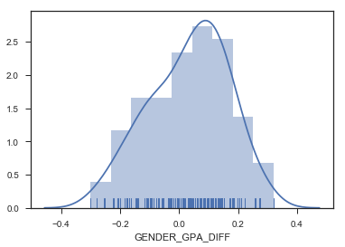

```python
sns.distplot(pivoted_data['GENDER_GPA_DIFF'], kde=True, rug=True)
```

But is this difference, a mean of 0.032, statistically significant? The distribution of 'GENDER_GPA_DIFF' isn't exactly normal, but it's close. Let's try doing some inference:

H_0: GENDER_GPA_DIFF = 0

H_1: GENDER_GPA_DIFF != 0

```python
men = pivoted_data['M']
women = pivoted_data['F']

test = stats.ttest_ind(men.dropna(), women.dropna())
print("The p-value for a two-sided test for the null hypothesis that male and female students have identical average (expected) values is", test[1])
print("We fail to reject the null hypothesis.")
```

```
The p-value for a two-sided test for the null hypothesis that male and female students have identical average (expected) values is 0.283088595622
We fail to reject the null hypothesis.
```

Okay, so we find that men and women perform similarly, even if on average, women do just a little bit better. Could this finding be affected by enrollment patterns? Let's explore:

```python
print("There are {0:d} studentCourse records for male students.".format(len(merged_filtered[merged_filtered['SEX'] == 'M'])))
print("There are {0:d} studentCourse records for female students.".format(len(merged_filtered[merged_filtered['SEX'] == 'F'])))
```

[output not shown]

So there are more records for female students. Are there more female students than men, or do they just take more classes?

```python
print("There are roughly similar number of male and female students. There are {0:d} men, and {1:d} women.".format(len(studentRecord[studentRecord['SEX'] == 'M']), len(studentRecord[studentRecord['SEX'] == 'F'])))
```

```
There are roughly similar number of male and female students. There are 69999 men, and 68889 women.
```

```python
# split data into men and women, then groupby and plot average gpa for each record.
men = merged_filtered[merged_filtered['SEX'] == 'M']
women = merged_filtered[merged_filtered['SEX'] == 'F']
```

```python
pivoted_men = men.pivot_table(index='ANONID',
                              values='GRD_PTS_PER_UNIT',
                              aggfunc='mean')

pivoted_women = women.pivot_table(index='ANONID',
                              values='GRD_PTS_PER_UNIT',
                              aggfunc='mean')
```

```python
pivoted_men.columns
```

```
Index(['GRD_PTS_PER_UNIT'], dtype='object')
```

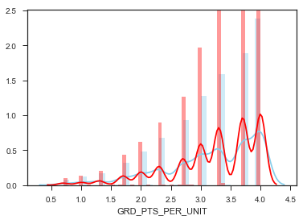

```python
sns.distplot(pivoted_men['GRD_PTS_PER_UNIT'], color="skyblue")
sns.distplot(pivoted_women['GRD_PTS_PER_UNIT'], color="red")
```

The last question we can ask is who would be the valedictorian? Would it be a female or male student?

```python
student_gpas = merged_filtered.groupby('ANONID').mean()
student_gpas.sort_values('GRD_PTS_PER_UNIT', ascending=False).head(10)
```

| ANONID | CATALOG_NBR | GRD_PTS_PER_UNIT | GPAO | ANON_INSTR_ID | TERM | HSGPA | LAST_ACT_ENGL_SCORE | LAST_ACT_MATH_SCORE | LAST_ACT_READ_SCORE | LAST_ACT_SCIRE_SCORE | LAST_ACT_COMP_SCORE | LAST_SATI_VERB_SCORE | LAST_SATI_MATH_SCORE | LAST_SATI_TOTAL_SCORE | ADMIT_TERM | MAJOR1_TERM | MAJOR2_TERM | MAJOR3_TERM |
| --- | --- | --- | --- | --- | --- | --- | --- | --- | --- | --- | --- | --- | --- | --- | --- | --- | --- | --- |
| 137755 | 250.0 | 4.0 | 3.945000 | 71.0 | 131.0 | 3.9 | 35.0 | 34.0 | 35.0 | 34.0 | 35.0 | NaN | NaN | NaN | 130.0 | NaN | NaN | NaN |
| 98544 | 250.0 | 4.0 | 3.668852 | 1446.0 | 135.0 | 3.9 | 33.0 | 34.0 | 29.0 | 35.0 | 33.0 | NaN | NaN | NaN | 134.0 | NaN | NaN | NaN |
| 42952 | 250.0 | 4.0 | 3.752500 | 1802.0 | 123.0 | 3.9 | 30.0 | 35.0 | 28.0 | 32.0 | 32.0 | NaN | NaN | NaN | 122.0 | 135.0 | 135.0 | NaN |
| 42933 | 250.0 | 4.0 | 3.671930 | 1260.0 | 135.0 | 3.9 | 30.0 | 34.0 | NaN | NaN | 31.0 | 720.0 | 790.0 | 1510.0 | 134.0 | NaN | NaN | NaN |
| 94974 | 250.0 | 4.0 | 3.926667 | 386.0 | 122.0 | 4.0 | 36.0 | 35.0 | 36.0 | 35.0 | 36.0 | 770.0 | 790.0 | 1560.0 | 118.0 | 131.0 | NaN | NaN |
| 161961 | 250.0 | 4.0 | 3.933333 | 1446.0 | 135.0 | 4.0 | 34.0 | 32.0 | 35.0 | 32.0 | 34.0 | 730.0 | 660.0 | 1390.0 | 130.0 | NaN | NaN | NaN |
| 42914 | 250.0 | 4.0 | 3.637288 | 1260.0 | 131.0 | 4.0 | 31.0 | 32.0 | 31.0 | 30.0 | 31.0 | NaN | NaN | NaN | 130.0 | NaN | NaN | NaN |
| 42898 | 250.0 | 4.0 | 3.442991 | 1260.0 | 122.0 | 3.9 | 34.0 | 27.0 | NaN | NaN | 29.0 | 710.0 | 650.0 | 1360.0 | 118.0 | 131.0 | 131.0 | NaN |
| 94987 | 250.0 | 4.0 | 3.813793 | 386.0 | 123.0 | 3.9 | 35.0 | 34.0 | 36.0 | 36.0 | 36.0 | NaN | NaN | NaN | 118.0 | 131.0 | 131.0 | NaN |
| 95030 | 250.0 | 4.0 | 3.865306 | 1260.0 | 127.0 | 0.0 | 32.0 | 32.0 | NaN | NaN | 28.0 | 580.0 | 710.0 | 1290.0 | 122.0 | 135.0 | NaN | NaN |

This highlights a limitation in our data analysis. We can take the average of "GRD_PTS_PER_UNIT," which is the students performance in all classes in the database. But for most students, this is not equal to "CUM_GPA" which is their cumulative GPA or "GPAO". But that excludes the gpa earned for the class in that row. As a result, what I've done above doesn't tell us much. ANONID == 137755 has earned A's in all of the classes for which we have data, but her "GPAO" is 3.945. So this data exploration wasn't so helpful.

Okay, finally, how do average grades vary by DIV (division of the subject, e.g., "professional")?

```python
pivoted_types = merged_filtered.pivot_table(index='DIV',
                                            columns='SEX',
                                            values='GRD_PTS_PER_UNIT',
                                            aggfunc='mean')
pivoted_types
```

| SEX DIV | F | M |
| --- | --- | --- |
| E | 3.089415 | 3.149046 |
| H | 3.405232 | 3.277919 |
| O | 3.899194 | 3.860293 |
| P | 3.234797 | 3.253686 |
| S | 3.022402 | 3.060147 |
| SS | 3.281688 | 3.148622 |

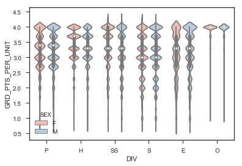

```python
sns.violinplot(x="DIV", y="GRD_PTS_PER_UNIT", hue="SEX", data=merged_filtered, palette="Pastel1")
```

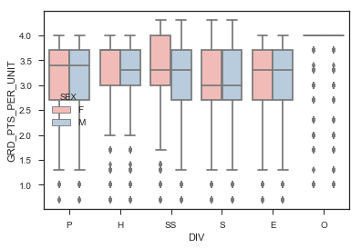

```python
sns.boxplot(x="DIV", y="GRD_PTS_PER_UNIT", hue="SEX", data=merged_filtered, palette="Pastel1")
```

This is a good example of when a boxplot is easier to understand visually than a violin plot -- there's just too much going on above.

## Q7: List the 5 courses that represnt the largest (absolute) difference in mean between males and females along with the value of the difference.

```python
# Show your code here
# Hint: use your pivoted_data from Q4 & Q5
top5_diff = pivoted_data.nlargest(5, 'GENDER_GPA_ABS_DIFF')
top5_diff = top5_diff.drop(['F','M','GENDER_GPA_DIFF'], axis=1)
top5_diff
```

| SEX COURSE | GENDER_GPA_ABS_DIFF |
| --- | --- |
| PSYCH350 | 0.319565 |
| ECON101 | 0.299533 |
| PHYSICS140 | 0.278921 |
| SPANISH101 | 0.274112 |
| BUDDHST230 | 0.274093 |

```python
top5_course = pd.merge(merged_filtered, top5_diff, left_on='COURSE', right_index=True, )
top5_course.head()
```

|  | ANONID | SUBJECT | CATALOG_NBR | GRD_PTS_PER_UNIT | GPAO | DIV | ANON_INSTR_ID | TERM | MAJOR3_DESCR | MAJOR2_DESCR | ... | STDNT_GROUP2 | MAJOR1_DEPT | MAJOR2_DEPT | MAJOR3_DEPT | ADMIT_TERM | MAJOR1_TERM | MAJOR2_TERM | MAJOR3_TERM | COURSE | GENDER_GPA_ABS_DIFF |
| --- | --- | --- | --- | --- | --- | --- | --- | --- | --- | --- | --- | --- | --- | --- | --- | --- | --- | --- | --- | --- | --- |
| 80008 | 750 | BUDDHST | 230 | 3.7 | 3.910000 | H | 628 | 78 | NaN | NaN | ... | NaN | College of Literature, Science, and the Arts | NaN | NaN | 75.0 | 92.0 | NaN | NaN | BUDDHST230 | 0.274093 |
| 80009 | 1719 | BUDDHST | 230 | 4.0 | 2.850000 | H | 628 | 78 | NaN | NaN | ... | NaN | College of Literature, Science, and the Arts | NaN | NaN | 63.0 | 84.0 | NaN | NaN | BUDDHST230 | 0.274093 |
| 80010 | 5154 | BUDDHST | 230 | 3.3 | 3.150000 | H | 628 | 78 | NaN | NaN | ... | NaN | English Language & Literature Dept | NaN | NaN | 68.0 | 84.0 | NaN | NaN | BUDDHST230 | 0.274093 |
| 80011 | 5620 | BUDDHST | 230 | 3.7 | 2.739604 | H | 628 | 78 | NaN | NaN | ... | NaN | History Department | NaN | NaN | 78.0 | 94.0 | NaN | NaN | BUDDHST230 | 0.274093 |
| 80012 | 7409 | BUDDHST | 230 | 2.3 | 2.324590 | H | 628 | 78 | NaN | NaN | ... | NaN | NaN | NaN | NaN | 68.0 | NaN | NaN | NaN | BUDDHST230 | 0.274093 |

5 rows × 32 columns

```python
len(top5_course)
```

```
62324
```

```python
course = top5_course[top5_course['COURSE'] == 'BUDDHST230']
print(len(course))
```

```
210
```

```python
course.head()
```

|  | ANONID | SUBJECT | CATALOG_NBR | GRD_PTS_PER_UNIT | GPAO | DIV | ANON_INSTR_ID | TERM | MAJOR3_DESCR | MAJOR2_DESCR | ... | STDNT_GROUP2 | MAJOR1_DEPT | MAJOR2_DEPT | MAJOR3_DEPT | ADMIT_TERM | MAJOR1_TERM | MAJOR2_TERM | MAJOR3_TERM | COURSE | GENDER_GPA_ABS_DIFF |
| --- | --- | --- | --- | --- | --- | --- | --- | --- | --- | --- | --- | --- | --- | --- | --- | --- | --- | --- | --- | --- | --- |
| 80008 | 750 | BUDDHST | 230 | 3.7 | 3.910000 | H | 628 | 78 | NaN | NaN | ... | NaN | College of Literature, Science, and the Arts | NaN | NaN | 75.0 | 92.0 | NaN | NaN | BUDDHST230 | 0.274093 |
| 80009 | 1719 | BUDDHST | 230 | 4.0 | 2.850000 | H | 628 | 78 | NaN | NaN | ... | NaN | College of Literature, Science, and the Arts | NaN | NaN | 63.0 | 84.0 | NaN | NaN | BUDDHST230 | 0.274093 |
| 80010 | 5154 | BUDDHST | 230 | 3.3 | 3.150000 | H | 628 | 78 | NaN | NaN | ... | NaN | English Language & Literature Dept | NaN | NaN | 68.0 | 84.0 | NaN | NaN | BUDDHST230 | 0.274093 |
| 80011 | 5620 | BUDDHST | 230 | 3.7 | 2.739604 | H | 628 | 78 | NaN | NaN | ... | NaN | History Department | NaN | NaN | 78.0 | 94.0 | NaN | NaN | BUDDHST230 | 0.274093 |
| 80012 | 7409 | BUDDHST | 230 | 2.3 | 2.324590 | H | 628 | 78 | NaN | NaN | ... | NaN | NaN | NaN | NaN | 68.0 | NaN | NaN | NaN | BUDDHST230 | 0.274093 |

5 rows × 32 columns

```python
men = course[course['SEX'] = 'M']
women = course[course['SEX'] = 'F']
```

## Q8: Use sns.distplot(...) to show the distributions of GRD_PTS_PER_UNIT of males and females for each of those 5 courses.

You should have a total of 5 plots, each with two distributions (one for males and one fof females). The plot should look similar to this:

[figure not shown]

```python
def plot_course(course):

    c = top5_course[top5_course['COURSE'] == course]
    m = c[c['SEX'] == 'M']
    f = c[c['SEX'] == 'F']

    fig, ax = plt.subplots()
    sns.distplot(m.GRD_PTS_PER_UNIT, ax=ax, kde=True, color='b')
    sns.distplot(f.GRD_PTS_PER_UNIT, ax=ax, kde=True, color='r')
    ax.set_xlim([0, 4.3])
    ax.set_ylim([0,3])
```

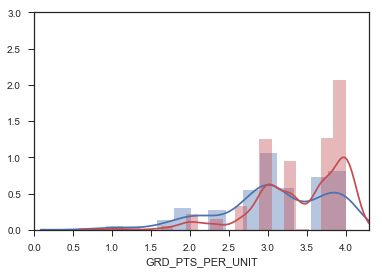

```python
plot_course('PSYCH350')
```

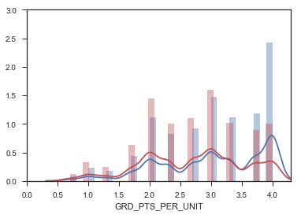

```python
plot_course('ECON101')
```

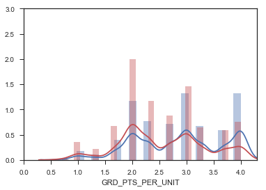

```python
plot_course('PHYSICS140')
```

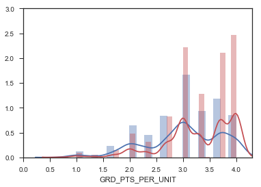

```python
plot_course('SPANISH101')
```

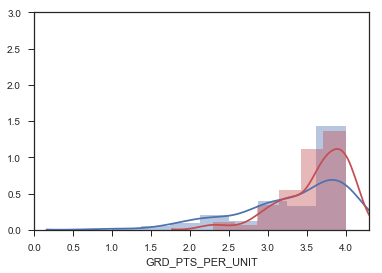

```python
plot_course('BUDDHST230')
```

## Q9: Describe, in your own words, how the distributions histograms you generated do or do not show the differences in the means you reported in Q2

These graphs show the distribution of grades earned by gender, where as the difference in means (reported in Q4) show just the average. Plotting all of the data, not just the averages, allows us to see gender differences. Doing so allows university administrators to see relevant information about student performance in these courses. For example:

# Time to learn something new

We learned about pivot, stack, unstack, and pivot_table earlier in the course. What we didn't learn was how to "unpivot" data. In pandas, you use the "melt" function to do that. You will need to use melt() for the next step.

The Student Record data set has three columns to represent the departments that correspond to the first three majors that each student has declared. The order of those isn't important. Not all students have three majors, so some of those fields will be blank.

We want to get a list of all the departments that each student is in, for every row in the joined table (i.e. the one you generated earlier that joins Student Course and Student Record). So if a student was in a major that belonged to the Psychology Department and another one that belonged to "English Language & Literature Dept", and that student had taken STATS250 and ECON101, there would be 4 rows for that student in the resulting table: one row that indicated the student was in the Psychology Department and had taken STATS250, a second one that indicated the student was in English and had taken STATS250, a third one that indicated they were in Psychology and had taken ECON101, and a fourth one indicating they were in English and had taken ECON 101. That's what we mean by "unpivoting" (or, in our case, melt()ing).

Here's what the syntax for the melt() is going to look like:

```
joined.melt(id_vars='ANONID',
                     value_vars=['MAJOR1_DEPT','MAJOR2_DEPT','MAJOR3_DEPT'],
                     value_name='DEPT',
                     var_name='DEPT_NBR')
```

Copy that below, and assign it to `melted`

The following code assumes the joined DataFrame you generated above is called "joined"

```python
merged.head()
```

|  | ANONID | SUBJECT | CATALOG_NBR | GRD_PTS_PER_UNIT | GPAO | DIV | ANON_INSTR_ID | TERM | MAJOR3_DESCR | MAJOR2_DESCR | ... | SEX | STDNT_GROUP1 | STDNT_GROUP2 | MAJOR1_DEPT | MAJOR2_DEPT | MAJOR3_DEPT | ADMIT_TERM | MAJOR1_TERM | MAJOR2_TERM | MAJOR3_TERM |
| --- | --- | --- | --- | --- | --- | --- | --- | --- | --- | --- | --- | --- | --- | --- | --- | --- | --- | --- | --- | --- | --- |
| 0 | 26 | ACC | 272 | 2.0 | 3.343636 | P | 2920 | 79 | NaN | NaN | ... | F | NaN | NaN | College of Literature, Science, and the Arts | NaN | NaN | 73.0 | 89.0 | NaN | NaN |
| 1 | 114 | ACC | 272 | 2.0 | 2.817857 | P | 2920 | 83 | NaN | NaN | ... | F | NaN | NaN | Economics Department | NaN | NaN | 78.0 | 93.0 | NaN | NaN |
| 2 | 121 | ACC | 272 | 4.0 | 4.000000 | P | 201 | 111 | NaN | NaN | ... | F | NaN | NaN | School of Business Administration | NaN | NaN | 106.0 | 119.0 | NaN | NaN |
| 3 | 125 | ACC | 272 | 1.3 | 3.639063 | P | 3360 | 84 | NaN | NaN | ... | F | NaN | NaN | Psychology Department | NaN | NaN | 78.0 | 94.0 | NaN | NaN |
| 4 | 180 | ACC | 272 | 3.0 | 3.846154 | P | 2920 | 107 | NaN | NaN | ... | M | NaN | NaN | School of Business Administration | NaN | NaN | 102.0 | 115.0 | NaN | NaN |

5 rows × 30 columns

```python
melted = merged.melt(id_vars='ANONID',
                     value_vars=['MAJOR1_DEPT','MAJOR2_DEPT','MAJOR3_DEPT'],
                     value_name='DEPT',
                     var_name='DEPT_NBR')
```

Now take a look at melted

```python
melted.head(20)
```

|  | ANONID | DEPT_NBR | DEPT |
| --- | --- | --- | --- |
| 0 | 26 | MAJOR1_DEPT | College of Literature, Science, and the Arts |
| 1 | 114 | MAJOR1_DEPT | Economics Department |
| 2 | 121 | MAJOR1_DEPT | School of Business Administration |
| 3 | 125 | MAJOR1_DEPT | Psychology Department |
| 4 | 180 | MAJOR1_DEPT | School of Business Administration |
| 5 | 207 | MAJOR1_DEPT | Mathematics Department |
| 6 | 224 | MAJOR1_DEPT | English Language & Literature Dept |
| 7 | 249 | MAJOR1_DEPT | School of Business Administration |
| 8 | 356 | MAJOR1_DEPT | Political Science Department |
| 9 | 400 | MAJOR1_DEPT | School of Business Administration |
| 10 | 484 | MAJOR1_DEPT | Chemistry Department |
| 11 | 509 | MAJOR1_DEPT | School of Business Administration |
| 12 | 531 | MAJOR1_DEPT | Economics Department |
| 13 | 533 | MAJOR1_DEPT | School of Business Administration |
| 14 | 553 | MAJOR1_DEPT | Economics Department |
| 15 | 577 | MAJOR1_DEPT | School of Business Administration |
| 16 | 624 | MAJOR1_DEPT | School of Business Administration |
| 17 | 685 | MAJOR1_DEPT | School of Business Administration |
| 18 | 706 | MAJOR1_DEPT | School of Business Administration |
| 19 | 710 | MAJOR1_DEPT | School of Business Administration |

We don't really care about the DEPT_NBR column, but it's not causing problems so we can just leave it there.

Next, we want to drop the NaN values (using .dropna()), and then merge it with the "joined" dataframe you generated earlier.

Finally, drop all duplicate rows (.drop_duplicates()).

```python
melted = melted.dropna()

merged_filtered = merged_filtered[(merged_filtered['COURSE'] == 'PSYCH360') | (merged_filtered['COURSE'] == 'STATS250')]

joined_table = pd.merge(merged_filtered, melted, on='ANONID', how='inner')

joined_table = joined_table.drop_duplicates()

joined_table.drop_duplicates(inplace=True)
```

```python
joined_table.head(10)
```

|  | ANONID | SUBJECT | CATALOG_NBR | GRD_PTS_PER_UNIT | GPAO | DIV | ANON_INSTR_ID | TERM | MAJOR3_DESCR | MAJOR2_DESCR | ... | MAJOR1_DEPT | MAJOR2_DEPT | MAJOR3_DEPT | ADMIT_TERM | MAJOR1_TERM | MAJOR2_TERM | MAJOR3_TERM | COURSE | DEPT_NBR | DEPT |
| --- | --- | --- | --- | --- | --- | --- | --- | --- | --- | --- | --- | --- | --- | --- | --- | --- | --- | --- | --- | --- | --- |
| 0 | 523 | PSYCH | 360 | 4.0 | 3.815200 | SS | 3604 | 74 | NaN | NaN | ... | Political Science Department | NaN | NaN | 63.0 | 79.0 | NaN | NaN | PSYCH360 | MAJOR1_DEPT | Political Science Department |
| 11 | 553 | PSYCH | 360 | 3.3 | 3.630769 | SS | 3604 | 64 | NaN | NaN | ... | Economics Department | NaN | NaN | 59.0 | 74.0 | NaN | NaN | PSYCH360 | MAJOR1_DEPT | Economics Department |
| 20 | 1021 | PSYCH | 360 | 3.0 | 2.419000 | SS | 3604 | 74 | NaN | NaN | ... | Psychology Department | NaN | NaN | 59.0 | 77.0 | NaN | NaN | PSYCH360 | MAJOR1_DEPT | Psychology Department |
| 27 | 1181 | PSYCH | 360 | 3.7 | 2.727419 | SS | 3604 | 63 | NaN | NaN | ... | School Of Kinesiology | NaN | NaN | 55.0 | 64.0 | NaN | NaN | PSYCH360 | MAJOR1_DEPT | School Of Kinesiology |
| 30 | 1623 | PSYCH | 360 | 2.3 | 3.282857 | SS | 3604 | 73 | NaN | NaN | ... | College of Literature, Science, and the Arts | NaN | NaN | 59.0 | 74.0 | NaN | NaN | PSYCH360 | MAJOR1_DEPT | College of Literature, Science, and the Arts |
| 39 | 2164 | PSYCH | 360 | 2.7 | 2.731111 | SS | 3604 | 68 | NaN | NaN | ... | College of Literature, Science, and the Arts | NaN | NaN | 59.0 | 74.0 | NaN | NaN | PSYCH360 | MAJOR1_DEPT | College of Literature, Science, and the Arts |
| 42 | 2304 | PSYCH | 360 | 2.7 | 3.361667 | SS | 3604 | 64 | NaN | NaN | ... | Psychology Department | NaN | NaN | NaN | 64.0 | NaN | NaN | PSYCH360 | MAJOR1_DEPT | Psychology Department |
| 44 | 2308 | PSYCH | 360 | 4.0 | 3.977215 | SS | 1732 | 78 | NaN | NaN | ... | Psychology Department | NaN | NaN | NaN | 79.0 | NaN | NaN | PSYCH360 | MAJOR1_DEPT | Psychology Department |
| 57 | 2311 | PSYCH | 360 | 3.7 | 3.129032 | SS | 3604 | 74 | NaN | Economics BA | ... | Psychology Department | Economics Department | NaN | 63.0 | 79.0 | 79.0 | NaN | PSYCH360 | MAJOR1_DEPT | Psychology Department |
| 75 | 2311 | PSYCH | 360 | 3.7 | 3.129032 | SS | 3604 | 74 | NaN | Economics BA | ... | Psychology Department | Economics Department | NaN | 63.0 | 79.0 | 79.0 | NaN | PSYCH360 | MAJOR2_DEPT | Economics Department |

10 rows × 33 columns

## Q10: Do students in majors from the Psychology Department do better in PSYCH360 than students who are not in Psychology Department majors?

**Use the resulting table to create a plot to visually investigate the differences of students' GRD_PTS_PER_UNIT in PSYCH360, comparing the GRD_PTS_PER_UNIT for students in Psychology Department majors vs. those who were not in Psychology Department majors. Based on your plots, answer the question.**

```python
psych_filtered = joined_table[joined_table['COURSE'] == 'PSYCH360']
len(psych_filtered)
```

```
1507
```

We need to drop rows for student who are in psych and another major. Otherwise, their performance will be counted twice -- in the plot of psych majors, and the plot of non-psych. Even if you're a double major with psych and another department, you should be counted as psych.

```python
psych_majors = psych_filtered[psych_filtered['DEPT'] == 'Psychology Department']
len(psych_majors)
```

```
470
```

```python
# this code drops double majors with psych from the non-psych pool of students
other_majors = psych_filtered[(psych_filtered['MAJOR1_DEPT'] != 'Psychology Department') &
                             (psych_filtered['MAJOR2_DEPT'] != 'Psychology Department') &
                             (psych_filtered['MAJOR3_DEPT'] != 'Psychology Department')]
len(other_majors)
```

```
881
```

```python
print("There are {0:d} psych majors in PSYCH360, including students double and triple majoring.".format(len(psych_majors)))
print("There are {0:d} non-pysch majors in PSYCH360.".format(len(other_majors)))
```

```
There are 470 psych majors in PSYCH360, including students double and triple majoring.
There are 881 non-pysch majors in PSYCH360.
```

```python
print("The simple truth? Psych majors on average do better than non-psych majors. The average grade for a psych major in PSYCH250 is {0:.2f}, while students outside the major earn {1:.2f}.". format(psych_majors.GRD_PTS_PER_UNIT.mean(),other_majors.GRD_PTS_PER_UNIT.mean()))
```

[output not shown]

## The answer:

```python
test = stats.ttest_ind(psych_majors.GRD_PTS_PER_UNIT.dropna(), other_majors.GRD_PTS_PER_UNIT.dropna())
print("Still not convinced? The p-value for a two-sided test for the null hypothesis that psych majors and non-psych majors have identical average (expected) grades is {0:.4f}.".format(test[1]))
```

```
Still not convinced? The p-value for a two-sided test for the null hypothesis that psych majors and non-psych majors have identical average (expected) grades is 0.0007.
```

```
(0, 2)
```

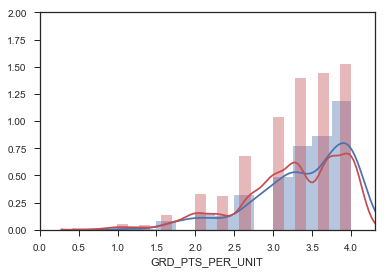

```python
fig, ax = plt.subplots()
sns.distplot(psych_majors.GRD_PTS_PER_UNIT, ax=ax, kde=True, color='b')
sns.distplot(other_majors.GRD_PTS_PER_UNIT, ax=ax, kde=True, color='r')
ax.set_xlim([0, 4.3])
ax.set_ylim([0, 2])
```

We can also do box and displots.

```
[Text(0.5,0,'')]
```

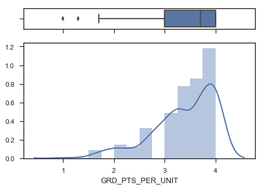

```python
f, (ax_box, ax_hist) = plt.subplots(2, sharex=True, gridspec_kw={"height_ratios": (.15, .85)})
sns.boxplot(psych_majors['GRD_PTS_PER_UNIT'], ax=ax_box)
sns.distplot(psych_majors['GRD_PTS_PER_UNIT'], ax=ax_hist)
ax_box.set(xlabel='')
```

```
[Text(0.5,0,'')]
```

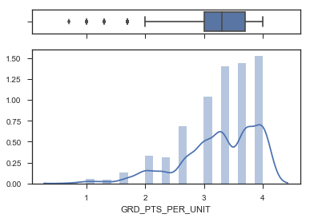

```python
f, (ax_box, ax_hist) = plt.subplots(2, sharex=True, gridspec_kw={"height_ratios": (.15, .85)})
sns.boxplot(other_majors['GRD_PTS_PER_UNIT'], ax=ax_box)
sns.distplot(other_majors['GRD_PTS_PER_UNIT'], ax=ax_hist)
ax_box.set(xlabel='')
```

Finally, we are going to use the multiplePlots() function from our in-class lab to investigate the distribution of GPAO of students in STATS250 who are in majors from the Psychology Department, split by sex.

You'll need to generate two grids (one for males and one for females), each containing four plots (a histogram of the distribution, a run sequence, a lag plot, and a Q-Q plot) for the GPAO variable. Select only students who are in majors from the Psychology Department who are taking STATS250.

## Q11: Do the GPAO scores for males and females taking STATS250 who are in majors from the Psychology Department appear to be normally distributed? Explain why or why not.

```python
# Copy the multiplePlots function here.
def multiplePlots( series ):

    fig, axs = plt.subplots(2,2)
    plt.tight_layout(pad=0.4, w_pad=4, h_pad=1.0)

    # Histogram
    sns.distplot(series, ax=axs[0,0])

    # Lag plot
    lag = series.copy()
    lag = np.array(lag[:-1])
    current = series[1:]
    ax = sns.regplot(current,lag,fit_reg=False, ax=axs[0,1])
    ax.set_ylabel("y_i-1")
    ax.set_xlabel("y_i")

    # QQ plot
    qntls, xr = stats.probplot(series, fit=False)
    sns.regplot(xr,qntls, ax=axs[1,0])

    # Run sequence
    ax = sns.regplot(np.arange(len(series)),series, ax=axs[1,1])
    ax.set_ylabel("val")
    ax.set_xlabel("i")
```

```python
stats_filtered = joined_table[joined_table['COURSE'] == 'STATS250']
psych = stats_filtered[stats_filtered['DEPT'] == 'Psychology Department']
psych_m = psych[psych['SEX'] == 'M']
psych_f = psych[psych['SEX'] == 'F']
```

```python
print(len(psych_m))
print(len(psych_f))
```

```
464
1398
```

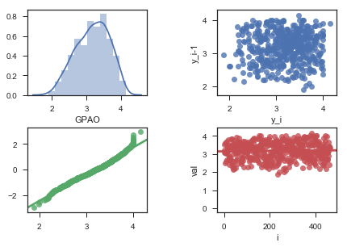

```python
multiplePlots(psych_m['GPAO'])
```

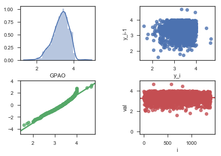

```python
multiplePlots(psych_f['GPAO'])
```

Yes, GPAO scores for both men and women appear to be roughly normal. How can we tell?

- Histograms are roughly normal (top left)
- Lag plot shows the structure is not deterministic (i.e., random) (top right)
- QQ plots are linear (although slightly skewed right for both men and women (bottom left)
- Run sequences show stable, fixed-variation (bottom right)

## Q12: Create a pairplot of 'GRD_PTS_PER_UNIT', 'HSGPA', 'LAST_SATI_VERB_SCORE', and 'LAST_SATI_MATH_SCORE'. What is your conclusion from the result?

```python
data = merged_filtered[['GRD_PTS_PER_UNIT',
                              'HSGPA',
                              'LAST_SATI_VERB_SCORE',
                              'LAST_SATI_MATH_SCORE']]
data.head(20)
```

|  | GRD_PTS_PER_UNIT | HSGPA | LAST_SATI_VERB_SCORE | LAST_SATI_MATH_SCORE |
| --- | --- | --- | --- | --- |
| 0 | 2.0 | 3.90 | NaN | NaN |
| 1 | 2.0 | 3.70 | NaN | NaN |
| 2 | 4.0 | 3.70 | 600.0 | 680.0 |
| 3 | 1.3 | 3.80 | NaN | NaN |
| 4 | 3.0 | 3.90 | NaN | NaN |
| 5 | 2.0 | 0.00 | 610.0 | 760.0 |
| 6 | 3.0 | 3.40 | NaN | NaN |
| 7 | 3.0 | 3.90 | 560.0 | 680.0 |
| 8 | 4.0 | 3.70 | 730.0 | 660.0 |
| 9 | 3.3 | 4.00 | NaN | NaN |
| 10 | 3.7 | 3.50 | NaN | NaN |
| 11 | 4.0 | 3.60 | 630.0 | 800.0 |
| 12 | 2.0 | 3.90 | 620.0 | 640.0 |
| 13 | 3.0 | 3.40 | 600.0 | 690.0 |
| 14 | 2.4 | 3.70 | NaN | NaN |
| 15 | 3.0 | 3.80 | NaN | NaN |
| 16 | 4.0 | 3.76 | 670.0 | 790.0 |
| 17 | 4.0 | 3.50 | NaN | NaN |
| 18 | 3.7 | 3.80 | NaN | NaN |
| 19 | 3.3 | 3.90 | NaN | NaN |

```python
# drop missing data for HS GPA -- which is making the pairplot graphs difficult to read!
data = data[data['HSGPA'] != 0]
```

```python
data = data.dropna()
```

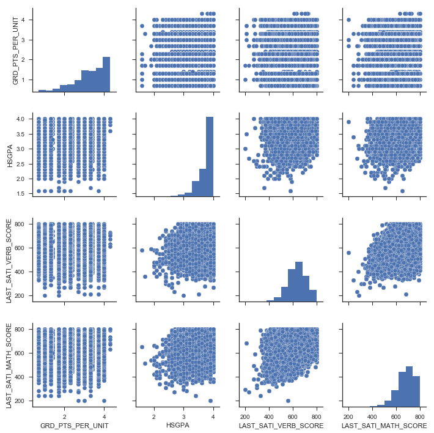

```python
sns.pairplot(data,dropna=True)
```

This pairplot tells us that HSGPA, and SAT math and verbal scores are not good predictors of performance in a course ('GRD_PTS_PER_UNIT'). There are students who did very well in these three measures of high school success who got low grades ('GRD_PTS_PER_UNIT'), but the opposite is also true. We also see a lot of variation in HSGPA and SAT -- this shouldn't be surprising. Some students are better in coursework, others in tests (i.e., the SAT) and some in both. We see this in our data because universities like students who are well-rounded, and they like a mix of students (those who worked really hard in high school, and those who show promise to do so with high test scores.)

# End of Homework 3